# Computing in Oceanography: data visualization

An important aspect of a scientist’s job is how to present or visualize their data. The goal is to **display information as clearly and simply as possible**.

Yesterday, we used an online plotting tool (Tuva) to make oceanographic profile plots. It was interactive, and fun to use, but there were some problems with it:

1. Pre-prepared and formatted dataset
2. Limited plotting options
3. Reproducibility

Excel or Google Sheets are platforms scientists use to do data visualization and analysis, but they can still have the same limitations as above, especially when we start to work with **a lot** of data. Often scientists in oceanography have a lot of data to deal with, and using computing and programming tools are becomming an indispensible part of doing science.

#### **Today’s Goal: learn how to plot oceanographic profiles using the computing language R**

### Set-up

1. Create a folder on your computer for the Computing in Oceanography work *don’t use spaces in the name!* e.g. `Jterm2020-computingInOceanography`
2. Create a subfolder (i.e. a folder within that folder) for today’s class e.g. `dataVisualization` (*again, no spaces!*)

## Introduction to R

### Installing R and RStudio

1. Install R program at: http://cran.rstudio.com/ . This site has options for download for Linux, Mac, and Windows
2. Install r-studio (R interface) http://www.rstudio.com/products/rstudio/download/ . Under “installers” you should see options for Mac and Windows

### R Basics

#### RStudio

RStudio is a program to help you use R. You can write a bunch of R commands in a *script*, you can access help and documentation, you can see any plots you make.

#### Set a working directory

At the start of a sesssion, set the working directory:

```r
setwd('V://Catherine//Teaching//MSSM//Jterm2020//Jterm2020-computingInOceanography//dataVisualization//')
```

Note: You will get error message if folder does not exist.

#### Use R as a calculator

```r
5+6
```

```
## [1] 11
```

```r
5*6
```

```
## [1] 30
```

```r
5/6
```

```
## [1] 0.8333333
```

#### Objects

You can assign values to an “object” (we call these *numeric*) e.g.

```r
x <- 5
y <- 6
x
```

```
## [1] 5
```

```r
x + y
```

```
## [1] 11
```

```r
y <- 5
x + y
```

```
## [1] 10
```

You can also assign letters or words to an object (we call these *characters* or *strings*) e.g.

```r
day <- "Monday"
day
```

```
## [1] "Monday"
```

```r
month <- "January"
month
```

```
## [1] "January"
```

You can have two objects together within another object e.g.

```r
dayMonth <- c(day,month)
dayMonth
```

```
## [1] "Monday"  "January"
```

This combined object `dayMonth` is called a *vector*, and each object within the vector is known as an *element*.

You can even mix up the types of objects, but the numeric is changed to a character e.g.

```r
mixedObject <- c(day,x,y,month)
mixedObject
```

```
## [1] "Monday"  "5"       "5"       "January"
```

i.e. the second and third elements within the mixedObject are no longer numbers, they are characters.

#### Indexing

If we have a vector, we can extract out one of the elements e.g.

```r
mixedObject[4]
```

```
## [1] "January"
```

Or we can extract however many elements we want, we just need to specify the location (or *index number*) of the element within the vector

```r
mixedObject[c(3,4)]
```

```
## [1] "5"       "January"
```

There’s lots of good resources online - **the internet is your friend when programming**.

## Plotting an oceanographic profile

#### Initialization

Launch R-studio and navigate to the directory you want to work in.

```r
setwd('V://Catherine//Teaching//MSSM//Jterm2020//Jterm2020-computingInOceanography//dataVisualization//')
```

#### Create a script

We are going to write all of our commands within a *script*. A script is just a document that has a series of R commands, and when you run it, all the commands are run in one go. It is **really useful** for redoing analyses, or remaking plots, or just remembering what you did yesterday.

#### Load data

Download the `20170912station4.csv` file from the Google Drive, located in:

`Computing in Oceanography\Data`

Save this file in the folder we created at the start of this session (i.e. our working directory, where our script is saved).

To load the data into R, type the following command at the start of your script:

```r
DATA <- read.csv('20170912station4.csv')
```

The data contained in that file are loaded into a variable (or object) called “DATA”, but we didn’t have to call the variable “DATA”. We could have called it something else, like “STATION_4”, “X”, or “Pinocchio”.

#### Aside: summary of data

If you are interested in all the data, you can look at a summary of what is in this variable.

```r
summary(DATA)
```

```
##       Date             Station     Depth.m        Temperature.C
##  Min.   :20170912   Min.   :4   Min.   :  0.791   Min.   : 6.835
##  1st Qu.:20170912   1st Qu.:4   1st Qu.: 22.797   1st Qu.: 7.321
##  Median :20170912   Median :4   Median : 46.926   Median : 9.669
##  Mean   :20170912   Mean   :4   Mean   : 52.258   Mean   : 9.858
##  3rd Qu.:20170912   3rd Qu.:4   3rd Qu.: 84.284   3rd Qu.:11.236
##  Max.   :20170912   Max.   :4   Max.   :106.927   Max.   :15.103
##   Salinity.PSU   Density.kg.m..3      PAR          Fluorescence.mg.m..3
##  Min.   :31.62   Min.   :23.35   Min.   :  0.000   Min.   :0.1046
##  1st Qu.:32.24   1st Qu.:24.58   1st Qu.:  0.000   1st Qu.:0.1527
##  Median :32.30   Median :24.89   Median :  0.383   Median :0.2755
##  Mean   :32.30   Mean   :24.83   Mean   : 60.088   Mean   :0.6058
##  3rd Qu.:32.56   3rd Qu.:25.46   3rd Qu.: 22.500   3rd Qu.:0.5544
##  Max.   :32.64   Max.   :25.58   Max.   :914.000   Max.   :2.9206
##  Turbidity.NTU       Beam.1.m..1    OxygenConcentration.umole.kg..1
##  Min.   :0.000200   Min.   :6.441   Min.   :206.3
##  1st Qu.:0.000400   1st Qu.:6.550   1st Qu.:212.1
##  Median :0.000600   Median :6.802   Median :220.5
##  Mean   :0.001059   Mean   :6.904   Mean   :227.8
##  3rd Qu.:0.001800   3rd Qu.:7.255   3rd Qu.:250.6
##  Max.   :0.003400   Max.   :7.950   Max.   :264.8
##  OxygenSaturation
##  Min.   : 68.87
##  1st Qu.: 71.49
##  Median : 78.26
##  Mean   : 81.49
##  3rd Qu.: 91.86
##  Max.   :102.79
```

#### Plotting the oceanographic profile.

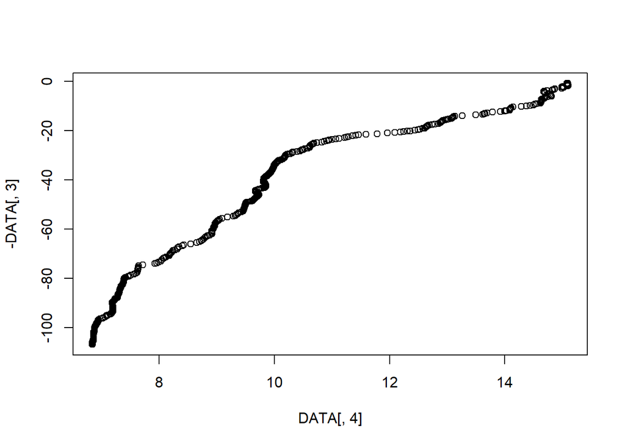

```r
plot(DATA[,4],-DATA[,3])
```

Another option is to use the column headings instead of the column numbers:

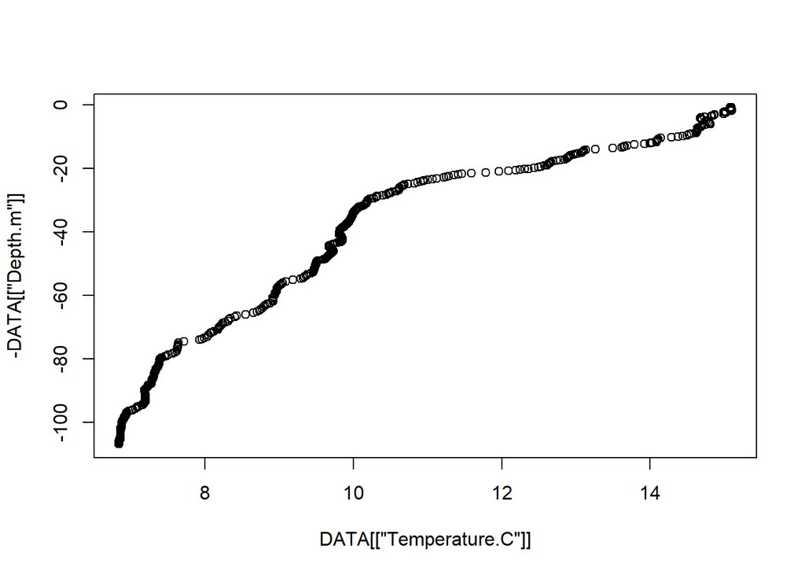

```r
plot(DATA[['Temperature.C']],-DATA[['Depth.m']])
```

#### Making the figure nicer

There are lots of options to customize the figure, but for now, we are just going to:

1. label the axes (xlab, ylab)
2. set the axis limits (xlim, ylim)
3. plot the data as a line with dots (type)
4. set the color of the data (col)

Add the following to your script:

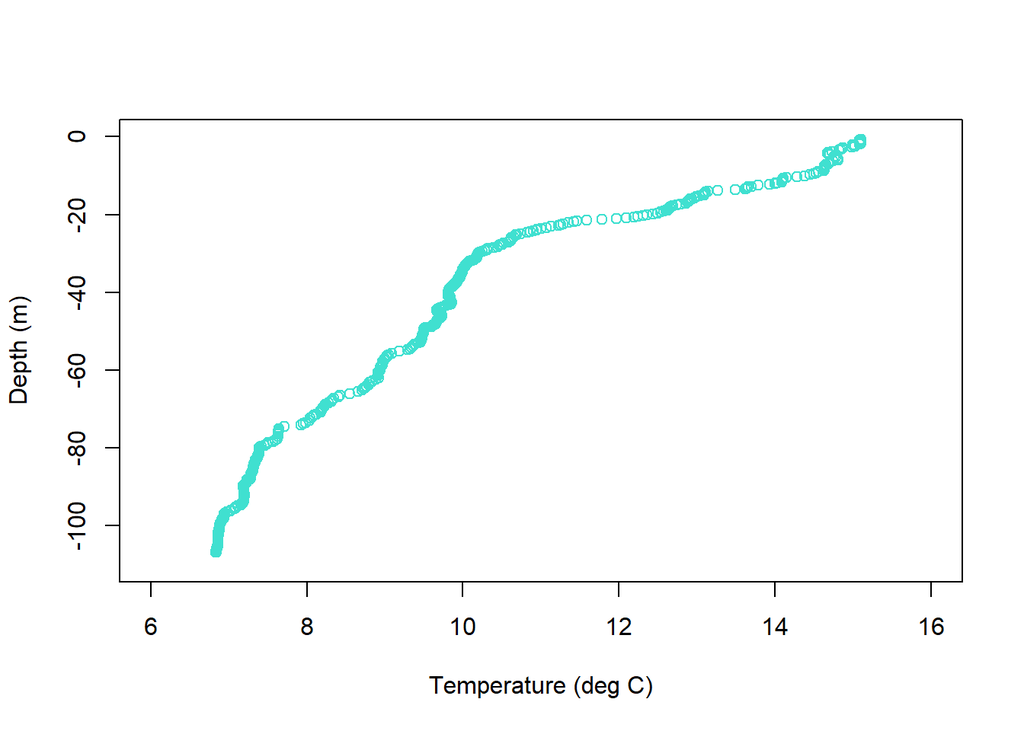

```r
plot(DATA[['Temperature.C']],-DATA[['Depth.m']],
 xlab='Temperature (deg C)',ylab='Depth (m)',
 xlim=c(6,16),ylim=c(-110,0),
 type="b",col="turquoise")
```

#### Save the figure

Type the following in your script

```r
png('temperature-station4-20170912.png')
plot(DATA[['Temperature.C']],-DATA[['Depth.m']],
 xlab='Temperature (deg C)',ylab='Depth (m)',
 xlim=c(6,16),ylim=c(-110,0),
 type="b",col="turquoise")
dev.off()
```

#### Save your script

Make sure you save your script, so you can run it again!